# HW04

DerekRBratcher

10/21/2021

# Homework 4

1. (3 points) Use the rvest R package to scrape the schedule and materials table into R from the course webpage (https://introdatasci.dlilab.com/schedule_materials/). Read the documentation of rvest so you get a better idea about the functions provided by rvest and their usages.

```r
library(rvest)
#designate the target /w read html and assign a name to the function
dilab_sched_mats<-read_html("https://introdatasci.dlilab.com/schedule_materials/")

#determine corresponding css label for the sched/materials table
SnM_table <- dilab_sched_mats %>% html_elements("table") |> html_table()

'SMdf'<-as.data.frame(SnM_table)
```

2. (2 points) With the extracted data frame, create two new columns based on the Date column: month and day. month would be the month abbrevations from the Date column; day would be the numeric numbers from the Date column. Although you can use whatever approach to get this done (do not enter them by hand…), I suggest you try to practice regular expression here (sub() or stringr::str_extract()).

```r
library(dplyr)
#extract days
days<-stringi::stri_sub(SMdf[, 1], -2,)
days<-as.numeric(days)
SMdf_new <- cbind(SMdf, days)

#create month columns
Month<-stringi::stri_sub(SMdf[, 1], from = 1, to = -3)
Month<- as.factor(Month)
Month_trim<- stringr::str_trim(Month, side = ("both"))
#not that it matters but how do you manipulate factor levels?
Months_<- factor(Month_trim, levels = c("Aug", "Sep", "Oct", "Nov", "Dec"))
SMdf_MD<-cbind(SMdf_new, Months_)

#eliminate reading, notes, hw column
SMdf_MD_trim<- SMdf_MD |> select(-Notes, -HW, -Reading)
SMdf_MD_trim
```

| Date | Topic | days | Months_ |
| --- | --- | --- | --- |
| Aug 24 | About the course | 24 | Aug |
| Aug 26 | Data science project cycle | 26 | Aug |
| Aug 31 | Class cancelled because of Hurricane Ida | 31 | Aug |
| Sep 2 | Class cancelled because of Hurricane Ida | 2 | Sep |
| Sep 7 | Introduction and install tools | 7 | Sep |
| Sep 9 | Version control with Git | 9 | Sep |
| Sep 14 | Introduction to GitHub | 14 | Sep |
| Sep 16 | RStudio project and dynamic documents with R Markdown | 16 | Sep |
| Sep 21 | The file system and basic unix shell | 21 | Sep |
| Sep 23 | R basics: data types, vectors, matrix, data frame, etc. | 23 | Sep |

[output cut: 20 more lines]

3. (2 points) With the data frame generated from Q2, use group_by() and summarise() to find out the number of lectures for each month, order the results by the number of lectures (high to low).

```r
#use group by month, the summarise to make new df with data from "month trim", count the number of months (n =()), only show distinct occurances with (distinct) and arrange in descending order make table a variable

lec_per_m<- SMdf_MD_trim |>  group_by(Months_) |> summarise( Months_, n =n()) |> distinct() |>  arrange( desc( n))
lec_per_m
```

| Months_ | n |
| --- | --- |
| Sep | 9 |
| Nov | 9 |
| Oct | 7 |
| Aug | 3 |
| Dec | 2 |

4. (3 points) For the Topic column, split all values into words (hint: stringr::str_split()). Observe the values in the Topic column and use regular expression to specify the pattern in the stringr::str_split() or strsplit() function. Once this is done, you should get a list of list, you can use unlist() to convert it into a vector and name it as words. Use table() and sort() to find the top 5 most frequent words.

```r
#use str_split to itemize each word into strings, make a list using regex and str_split, use unlist to make a vector then use table and sort to make a new table based on freq then sort to arrange by freq

topic_wrds<-stringr::str_split(SMdf_MD$Topic, " ")
#why doesnt following work help me understand subsetting
test_subset<- stringr::str_split(SMdf_MD["Topic"], " ")
#topic_wrds is now a list of strings each string corresponding to a topic and each character value is a word
topic_wrds
```

```
## [[1]]
## [1] "About"  "the"    "course"
##
## [[2]]
## [1] "Data"    "science" "project" "cycle"
##
## [[3]]
## [1] "Class"     "cancelled" "because"   "of"        "Hurricane" "Ida"
##
## [[4]]
## [1] "Class"     "cancelled" "because"   "of"        "Hurricane" "Ida"
##
## [[5]]
## [1] "Introduction" "and"          "install"      "tools"
##
## [[6]]
## [1] "Version" "control" "with"    "Git"
##
## [[7]]
## [1] "Introduction" "to"           "GitHub"
##
## [[8]]
## [1] "RStudio"   "project"   "and"       "dynamic"   "documents" "with"
## [7] "R"         "Markdown"
##
## [[9]]
## [1] "The"    "file"   "system" "and"    "basic"  "unix"   "shell"
##
## [[10]]
## [1] "R"        "basics:"  "data"     "types,"   "vectors," "matrix,"  "data"
## [8] "frame,"   "etc."
##
## [[11]]
## [1] "More"    "R"       "basics:" "lists,"  "dates,"  "etc."
##
## [[12]]
## [1] "R"           "programming" "basics:"     "conditional" "statements"
##
## [[13]]
## [1] "R"           "programming" "basics:"     "loops,"      "apply"
```

[output cut: 38 more lines]

```
## [[26]]
## [1] "Ethics"    "in"        "data"      "science"   "(virtual)"
##
## [[27]]
## [1] "Thanksgiving," "no"            "class"
##
## [[28]]
## [1] "Final"        "project"      "presentation"
##
## [[29]]
## [1] "Final"        "project"      "presentation" "and"          "wrap"
## [6] "up"
##
## [[30]]
## [1] "Final"  "grades" "due"
```

```r
as_words<-unlist(topic_wrds)
top5<-sort(prop.table(table(as_words)), decreasing = T)
top_5<-sort(table(as_words), decreasing = T)
top5
```

```
## as_words
##             R           and          data          with       basics:
##   0.064285714   0.057142857   0.042857143   0.042857143   0.028571429
##          Data       project         Final          More       because
##   0.028571429   0.028571429   0.021428571   0.021428571   0.014285714
##     cancelled         Class          etc.     Hurricane           Ida
##   0.014285714   0.014285714   0.014285714   0.014285714   0.014285714
##  Introduction  manipulation       methods            of           own
##   0.014285714   0.014285714   0.014285714   0.014285714   0.014285714
##  presentation   programming    Regression       science         Write
##   0.014285714   0.014285714   0.014285714   0.014285714   0.014285714
##          your     (virtual)         About      analysis           API
##   0.014285714   0.007142857   0.007142857   0.007142857   0.007142857
##         apply    automating         basic         class   conditional
##   0.007142857   0.007142857   0.007142857   0.007142857   0.007142857
##       control        course         cycle        dates,     documents
##   0.007142857   0.007142857   0.007142857   0.007142857   0.007142857
##           due       dynamic        Ethics   Exploratory   expressions
##   0.007142857   0.007142857   0.007142857   0.007142857   0.007142857
##          file        frame,     functions           Git        GitHub
##   0.007142857   0.007142857   0.007142857   0.007142857   0.007142857
##        grades            in         input       install        lists,
##   0.007142857   0.007142857   0.007142857   0.007142857   0.007142857
##        loops,      Makefile      Markdown       matrix,            no
##   0.007142857   0.007142857   0.007142857   0.007142857   0.007142857
##            on          Open        output       package       Regular
##   0.007142857   0.007142857   0.007142857   0.007142857   0.007142857
##       RStudio       Science      scraping         shell    statements
##   0.007142857   0.007142857   0.007142857   0.007142857   0.007142857
##       Strings        system Thanksgiving,           the           The
##   0.007142857   0.007142857   0.007142857   0.007142857   0.007142857
##        things            to         tools        types,          unix
##   0.007142857   0.007142857   0.007142857   0.007142857   0.007142857
##            up      vectors,       Version visualization          wrap
##   0.007142857   0.007142857   0.007142857   0.007142857   0.007142857
```

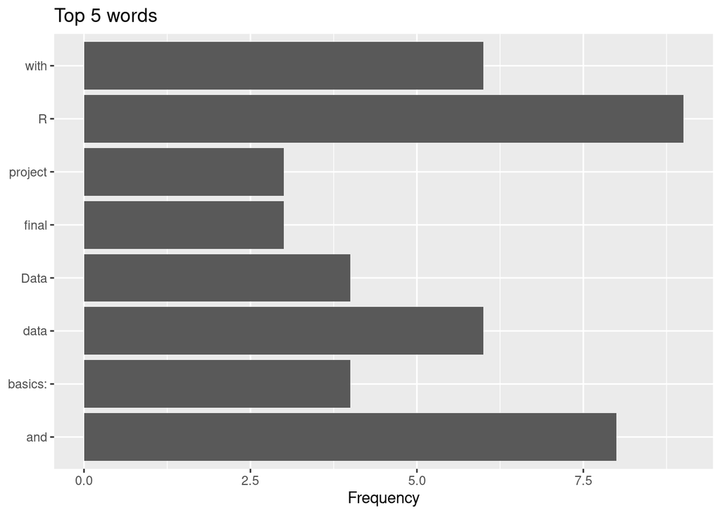

```r
#make a graph with ggplot?
library(ggplot2)
library(ggplot2)
top5df <- data.frame(stringsAsFactors=FALSE,
                 word = c("R", "and", "data", "with", "basics:", "Data", "project", "final"),                 freq = c(9, 8, 6, 6, 4, 4, 3, 3))

graph_top5_wrds<-ggplot(top5df, aes(word, freq)) +
geom_bar(stat="identity") +
coord_flip() +
labs(x = NULL, y = "Frequency") +
labs(title="Top 5 words ")
graph_top5_wrds
```

I was thinking to have a homework to get all plant occurrence data within Baton Rouge from GBIF. But it will require you to register an account and have account name and password when you use the rgbif package. This may have the risk of get your password leaked (you can avoid this by reading the documentation of rgbif); so I decided not to do so. If you are interested, you may want to run some example codes from the rgbif package’s documentation.

This homework will be due at October 28th, 9am.